# 23056348 Shashwat Ghimire

**1. IMPORT THE DATASET**

```python
import pandas as pd
import numpy as np
import matplotlib.pyplot as plt

data_set = pd.read_csv("Customer Service_Requests_from_2010_to_Present.csv", low_memory=False)
data_set
```

|  | Unique Key | Created Date | Closed Date | Agency | Agency Name | Complaint Type | Descriptor | Location Type | Incident Zip | Incident Address | ... | Bridge Highway Name | Bridge Highway Direction | Road Ramp | Bridge Highway Segment | Garage Lot Name | Ferry Direction | Ferry Terminal Name | Latitude | Longitude | Location |
| --- | --- | --- | --- | --- | --- | --- | --- | --- | --- | --- | --- | --- | --- | --- | --- | --- | --- | --- | --- | --- | --- |
| 0 | 32310363 | 12/31/2015 11:59:45 PM | 01-01-16 0:55 | NYPD | New York City Police Department | Noise - Street/Sidewalk | Loud Music/Party | Street/Sidewalk | 10034.0 | 71 VERMILYEA AVENUE | ... | NaN | NaN | NaN | NaN | NaN | NaN | NaN | 40.865682 | -73.923501 | (40.86568153633767, -73.92350095571744) |
| 1 | 32309934 | 12/31/2015 11:59:44 PM | 01-01-16 1:26 | NYPD | New York City Police Department | Blocked Driveway | No Access | Street/Sidewalk | 11105.0 | 27-07 23 AVENUE | ... | NaN | NaN | NaN | NaN | NaN | NaN | NaN | 40.775945 | -73.915094 | (40.775945312321085, -73.91509393898605) |
| 2 | 32309159 | 12/31/2015 11:59:29 PM | 01-01-16 4:51 | NYPD | New York City Police Department | Blocked Driveway | No Access | Street/Sidewalk | 10458.0 | 2897 VALENTINE AVENUE | ... | NaN | NaN | NaN | NaN | NaN | NaN | NaN | 40.870325 | -73.888525 | (40.870324522111424, -73.88852464418646) |
| 3 | 32305098 | 12/31/2015 11:57:46 PM | 01-01-16 7:43 | NYPD | New York City Police Department | Illegal Parking | Commercial Overnight Parking | Street/Sidewalk | 10461.0 | 2940 BAISLEY AVENUE | ... | NaN | NaN | NaN | NaN | NaN | NaN | NaN | 40.835994 | -73.828379 | (40.83599404683083, -73.82837939584206) |
| 4 | 32306529 | 12/31/2015 11:56:58 PM | 01-01-16 3:24 | NYPD | New York City Police Department | Illegal Parking | Blocked Sidewalk | Street/Sidewalk | 11373.0 | 87-14 57 ROAD | ... | NaN | NaN | NaN | NaN | NaN | NaN | NaN | 40.733060 | -73.874170 | (40.733059618956815, -73.87416975810375) |
| ... | ... | ... | ... | ... | ... | ... | ... | ... | ... | ... | ... | ... | ... | ... | ... | ... | ... | ... | ... | ... | ... |
| 300693 | 30281872 | 03/29/2015 12:33:41 AM | NaN | NYPD | New York City Police Department | Noise - Commercial | Loud Music/Party | Club/Bar/Restaurant | NaN | CRESCENT AVENUE | ... | NaN | NaN | NaN | NaN | NaN | NaN | NaN | NaN | NaN | NaN |
| 300694 | 30281230 | 03/29/2015 12:33:28 AM | 03/29/2015 02:33:59 AM | NYPD | New York City Police Department | Blocked Driveway | Partial Access | Street/Sidewalk | 11418.0 | 100-17 87 AVENUE | ... | NaN | NaN | NaN | NaN | NaN | NaN | NaN | 40.694077 | -73.846087 | (40.69407728322387, -73.8460866160573) |
| 300695 | 30283424 | 03/29/2015 12:33:03 AM | 03/29/2015 03:40:20 AM | NYPD | New York City Police Department | Noise - Commercial | Loud Music/Party | Club/Bar/Restaurant | 11206.0 | 162 THROOP AVENUE | ... | NaN | NaN | NaN | NaN | NaN | NaN | NaN | 40.699590 | -73.944234 | (40.69959035300927, -73.94423377144169) |
| 300696 | 30280004 | 03/29/2015 12:33:02 AM | 03/29/2015 04:38:35 AM | NYPD | New York City Police Department | Noise - Commercial | Loud Music/Party | Club/Bar/Restaurant | 10461.0 | 3151 EAST TREMONT AVENUE | ... | NaN | NaN | NaN | NaN | NaN | NaN | NaN | 40.837708 | -73.834587 | (40.8377075854206, -73.83458731019586) |
| 300697 | 30281825 | 03/29/2015 12:33:01 AM | 03/29/2015 04:41:50 AM | NYPD | New York City Police Department | Noise - Commercial | Loud Music/Party | Store/Commercial | 10036.0 | 251 WEST 48 STREET | ... | NaN | NaN | NaN | NaN | NaN | NaN | NaN | 40.760583 | -73.985922 | (40.76058322950115, -73.98592204392392) |

300698 rows × 53 columns

**INFO OF THE DATASET**

```python
data_set.info
```

[output not shown]

[output cut: 51 more lines]

**INITIAL SHAPE OF DATASET**

```python
data_set.describe
```

[output not shown]

[output cut: 51 more lines]

```python
data_set.shape
```

```
(300698, 53)
```

3. Convert the columns “Created Date” and “Closed Date” to datetime datatype and create a new column “Request_Closing_Time”.

```python
print(data_set['Created Date'].dtype)
print(data_set['Closed Date'].dtype)
```

```
object
object
```

```python
data_set['Created Date'] = pd.to_datetime(data_set['Created Date'],errors='coerce')
data_set['Closed Date'] = pd.to_datetime(data_set['Closed Date'],errors='coerce')

data_set['Request_Closing_Time'] = (data_set['Closed Date'] - data_set['Created Date']).dt.total_seconds() /3600
print(data_set[['Created Date', 'Closed Date', 'Request_Closing_Time']])

print(data_set['Created Date'].dtype)
print(data_set['Closed Date'].dtype)
```

```
              Created Date         Closed Date  Request_Closing_Time
0      2015-12-31 23:59:45 2016-01-01 00:55:00              0.920833
1      2015-12-31 23:59:44 2016-01-01 01:26:00              1.437778
2      2015-12-31 23:59:29 2016-01-01 04:51:00              4.858611
3      2015-12-31 23:57:46 2016-01-01 07:43:00              7.753889
4      2015-12-31 23:56:58 2016-01-01 03:24:00              3.450556
...                    ...                 ...                   ...
300693 2015-03-29 00:33:41                 NaT                   NaN
300694 2015-03-29 00:33:28 2015-03-29 02:33:59              2.008611
300695 2015-03-29 00:33:03 2015-03-29 03:40:20              3.121389
300696 2015-03-29 00:33:02 2015-03-29 04:38:35              4.092500
300697 2015-03-29 00:33:01 2015-03-29 04:41:50              4.146944

[300698 rows x 3 columns]
datetime64[ns]
datetime64[ns]
```

4. Write a python program to drop irrelevant Columns.

```python
data_set.shape
```

```
(300698, 54)
```

```python
irr_columns = [
    'Agency Name','Incident Address','Street Name','Cross Street 1','Cross Street 2','Intersection Street 1',
    'Intersection Street 2','Address Type','Park Facility Name','Park Borough','School Name', 'School Number',
    'School Region','School Code','School Phone Number','School Address','School City','School State','School Zip',
    'School Not Found','School or Citywide Complaint','Vehicle Type','Taxi Company Borough','Taxi Pick Up Location',
    'Bridge Highway Name','Bridge Highway Direction','Road Ramp','Bridge Highway Segment','Garage Lot Name',
    'Ferry Direction','Ferry Terminal Name','Landmark','X Coordinate (State Plane)','Y Coordinate (State Plane)',
    'Due Date','Resolution Action Updated Date','Community Board','Facility Type','Location'
]

data_set.drop(columns = irr_columns, inplace =True)

data_set.shape
```

```
(300698, 15)
```

```python
data_set
```

|  | Unique Key | Created Date | Closed Date | Agency | Complaint Type | Descriptor | Location Type | Incident Zip | City | Status | Resolution Description | Borough | Latitude | Longitude | Request_Closing_Time |
| --- | --- | --- | --- | --- | --- | --- | --- | --- | --- | --- | --- | --- | --- | --- | --- |
| 0 | 32310363 | 2015-12-31 23:59:45 | 2016-01-01 00:55:00 | NYPD | Noise - Street/Sidewalk | Loud Music/Party | Street/Sidewalk | 10034.0 | NEW YORK | Closed | The Police Department responded and upon arriv... | MANHATTAN | 40.865682 | -73.923501 | 0.920833 |
| 1 | 32309934 | 2015-12-31 23:59:44 | 2016-01-01 01:26:00 | NYPD | Blocked Driveway | No Access | Street/Sidewalk | 11105.0 | ASTORIA | Closed | The Police Department responded to the complai... | QUEENS | 40.775945 | -73.915094 | 1.437778 |
| 2 | 32309159 | 2015-12-31 23:59:29 | 2016-01-01 04:51:00 | NYPD | Blocked Driveway | No Access | Street/Sidewalk | 10458.0 | BRONX | Closed | The Police Department responded and upon arriv... | BRONX | 40.870325 | -73.888525 | 4.858611 |
| 3 | 32305098 | 2015-12-31 23:57:46 | 2016-01-01 07:43:00 | NYPD | Illegal Parking | Commercial Overnight Parking | Street/Sidewalk | 10461.0 | BRONX | Closed | The Police Department responded to the complai... | BRONX | 40.835994 | -73.828379 | 7.753889 |
| 4 | 32306529 | 2015-12-31 23:56:58 | 2016-01-01 03:24:00 | NYPD | Illegal Parking | Blocked Sidewalk | Street/Sidewalk | 11373.0 | ELMHURST | Closed | The Police Department responded and upon arriv... | QUEENS | 40.733060 | -73.874170 | 3.450556 |
| ... | ... | ... | ... | ... | ... | ... | ... | ... | ... | ... | ... | ... | ... | ... | ... |
| 300693 | 30281872 | 2015-03-29 00:33:41 | NaT | NYPD | Noise - Commercial | Loud Music/Party | Club/Bar/Restaurant | NaN | NaN | Open | Your complaint has been forwarded to the New Y... | Unspecified | NaN | NaN | NaN |
| 300694 | 30281230 | 2015-03-29 00:33:28 | 2015-03-29 02:33:59 | NYPD | Blocked Driveway | Partial Access | Street/Sidewalk | 11418.0 | RICHMOND HILL | Closed | The Police Department responded and upon arriv... | QUEENS | 40.694077 | -73.846087 | 2.008611 |
| 300695 | 30283424 | 2015-03-29 00:33:03 | 2015-03-29 03:40:20 | NYPD | Noise - Commercial | Loud Music/Party | Club/Bar/Restaurant | 11206.0 | BROOKLYN | Closed | The Police Department responded to the complai... | BROOKLYN | 40.699590 | -73.944234 | 3.121389 |
| 300696 | 30280004 | 2015-03-29 00:33:02 | 2015-03-29 04:38:35 | NYPD | Noise - Commercial | Loud Music/Party | Club/Bar/Restaurant | 10461.0 | BRONX | Closed | The Police Department responded to the complai... | BRONX | 40.837708 | -73.834587 | 4.092500 |
| 300697 | 30281825 | 2015-03-29 00:33:01 | 2015-03-29 04:41:50 | NYPD | Noise - Commercial | Loud Music/Party | Store/Commercial | 10036.0 | NEW YORK | Closed | The Police Department responded to the complai... | MANHATTAN | 40.760583 | -73.985922 | 4.146944 |

300698 rows × 15 columns

5. Write a python program to remove the NaN missing values from updated dataframe.

```python
data_set.shape
```

```
(300698, 15)
```

```python
data_set.dropna(inplace=True)
print(data_set.shape)
```

```
(291107, 15)
```

6. Write a python program to see the unique values from all the columns in the dataframe.

```python
for column in data_set.columns:
    unique_values = data_set[column].unique()
    print("\nColumn:", column)
    print("Number of unique values:", len(unique_values))

    example = unique_values[:3]
    print("Example:", example)
```

```
Column: Unique Key
Number of unique values: 291107
Example: [32310363 32309934 32309159]

Column: Created Date
Number of unique values: 251970
Example: <DatetimeArray>
['2015-12-31 23:59:45', '2015-12-31 23:59:44', '2015-12-31 23:59:29']
Length: 3, dtype: datetime64[ns]

Column: Closed Date
Number of unique values: 231991
Example: <DatetimeArray>
['2016-01-01 00:55:00', '2016-01-01 01:26:00', '2016-01-01 04:51:00']
Length: 3, dtype: datetime64[ns]

Column: Agency
Number of unique values: 1
Example: ['NYPD']

Column: Complaint Type
Number of unique values: 15
Example: ['Noise - Street/Sidewalk' 'Blocked Driveway' 'Illegal Parking']

Column: Descriptor
Number of unique values: 41
Example: ['Loud Music/Party' 'No Access' 'Commercial Overnight Parking']

Column: Location Type
Number of unique values: 14
Example: ['Street/Sidewalk' 'Club/Bar/Restaurant' 'Store/Commercial']

Column: Incident Zip
Number of unique values: 200
Example: [10034. 11105. 10458.]

Column: City
Number of unique values: 53
Example: ['NEW YORK' 'ASTORIA' 'BRONX']

```

[output cut: 10 more lines]

```
Column: Borough
Number of unique values: 5
Example: ['MANHATTAN' 'QUEENS' 'BRONX']

Column: Latitude
Number of unique values: 123013
Example: [40.86568154 40.77594531 40.87032452]

Column: Longitude
Number of unique values: 123112
Example: [-73.92350096 -73.91509394 -73.88852464]

Column: Request_Closing_Time
Number of unique values: 47134
Example: [0.92083333 1.43777778 4.85861111]
```

**IMPORTING SKEW AND KURTOSIS**

```python
from scipy.stats import skew, kurtosis
```

**DATA ANALYSIS**

1. Write a Python program to show summary statistics of sum, mean, standard deviation, skewness, and kurtosis of the data frame

```python
summary_stats = pd.DataFrame({
    'Sum': data_set.sum(numeric_only=True),
    'Mean': data_set.mean(numeric_only=True),
    'Std': data_set.std(numeric_only=True),
    'Skewness': data_set.skew(numeric_only=True),
    'Kurtosis': data_set.kurt(numeric_only=True)
})

summary_stats
```

|  | Sum | Mean | Std | Skewness | Kurtosis |
| --- | --- | --- | --- | --- | --- |
| Unique Key | 9.112108e+12 | 3.130158e+07 | 575377.738707 | 0.016898 | -1.176593 |
| Incident Zip | 3.160833e+09 | 1.085798e+04 | 580.280774 | -2.553956 | 37.827777 |
| Latitude | 1.185553e+07 | 4.072568e+01 | 0.082411 | 0.123114 | -0.734818 |
| Longitude | -2.152010e+07 | -7.392504e+01 | 0.078654 | -0.312739 | 1.455600 |
| Request_Closing_Time | 1.254358e+06 | 4.308926e+00 | 6.062641 | 14.299525 | 849.777081 |

2. Write a Python program to calculate and show correlation of all variables.

```python
summary_stats
```

|  | Sum | Mean | Std | Skewness | Kurtosis |
| --- | --- | --- | --- | --- | --- |
| Unique Key | 9.112108e+12 | 3.130158e+07 | 575377.738707 | 0.016898 | -1.176593 |
| Incident Zip | 3.160833e+09 | 1.085798e+04 | 580.280774 | -2.553956 | 37.827777 |
| Latitude | 1.185553e+07 | 4.072568e+01 | 0.082411 | 0.123114 | -0.734818 |
| Longitude | -2.152010e+07 | -7.392504e+01 | 0.078654 | -0.312739 | 1.455600 |
| Request_Closing_Time | 1.254358e+06 | 4.308926e+00 | 6.062641 | 14.299525 | 849.777081 |

```python
relevant_cols = ['Incident Zip', 'Latitude', 'Longitude', 'Request_Closing_Time']
corr_stats = data_set[relevant_cols].corr()
corr_stats
```

|  | Incident Zip | Latitude | Longitude | Request_Closing_Time |
| --- | --- | --- | --- | --- |
| Incident Zip | 1.000000 | -0.499081 | 0.385934 | 0.057182 |
| Latitude | -0.499081 | 1.000000 | 0.368819 | 0.024497 |
| Longitude | 0.385934 | 0.368819 | 1.000000 | 0.109724 |
| Request_Closing_Time | 0.057182 | 0.024497 | 0.109724 | 1.000000 |

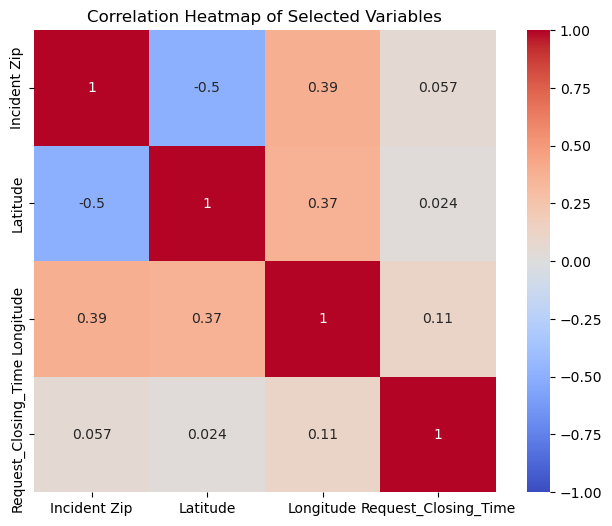

```python
import seaborn as sns
plt.figure(figsize=(8, 6))
sns.heatmap(corr_stats,
            annot=True,          #Display correlation values in the heatmap
            cmap='coolwarm',     #Color scheme (red for positive, blue for negative)
            vmin=-1, vmax=1,     #Range for correlation values
            center=0,            #Center the colormap at 0
            square=True)
plt.title('Correlation Heatmap of Selected Variables')
plt.show()
```

**DATA EXPLORATION**

1. Provide four major insights through visualization that you come up after data mining.

```python
data_set.head()
```

|  | Unique Key | Created Date | Closed Date | Agency | Complaint Type | Descriptor | Location Type | Incident Zip | City | Status | Resolution Description | Borough | Latitude | Longitude | Request_Closing_Time |
| --- | --- | --- | --- | --- | --- | --- | --- | --- | --- | --- | --- | --- | --- | --- | --- |
| 0 | 32310363 | 2015-12-31 23:59:45 | 2016-01-01 00:55:00 | NYPD | Noise - Street/Sidewalk | Loud Music/Party | Street/Sidewalk | 10034.0 | NEW YORK | Closed | The Police Department responded and upon arriv... | MANHATTAN | 40.865682 | -73.923501 | 0.920833 |
| 1 | 32309934 | 2015-12-31 23:59:44 | 2016-01-01 01:26:00 | NYPD | Blocked Driveway | No Access | Street/Sidewalk | 11105.0 | ASTORIA | Closed | The Police Department responded to the complai... | QUEENS | 40.775945 | -73.915094 | 1.437778 |
| 2 | 32309159 | 2015-12-31 23:59:29 | 2016-01-01 04:51:00 | NYPD | Blocked Driveway | No Access | Street/Sidewalk | 10458.0 | BRONX | Closed | The Police Department responded and upon arriv... | BRONX | 40.870325 | -73.888525 | 4.858611 |
| 3 | 32305098 | 2015-12-31 23:57:46 | 2016-01-01 07:43:00 | NYPD | Illegal Parking | Commercial Overnight Parking | Street/Sidewalk | 10461.0 | BRONX | Closed | The Police Department responded to the complai... | BRONX | 40.835994 | -73.828379 | 7.753889 |
| 4 | 32306529 | 2015-12-31 23:56:58 | 2016-01-01 03:24:00 | NYPD | Illegal Parking | Blocked Sidewalk | Street/Sidewalk | 11373.0 | ELMHURST | Closed | The Police Department responded and upon arriv... | QUEENS | 40.733060 | -73.874170 | 3.450556 |

**REQUEST CLOSING TIME AND COMPLAINT TYPE**

[figure not shown]

```python
plt.figure(figsize=(10, 6))
sns.lineplot(x='Complaint Type', y='Request_Closing_Time', data=data_set)
plt.xticks(rotation=45)
plt.title('Request Closing Time by Complaint Type')
plt.xlabel('Complaint Type')
plt.ylabel('Request Closing Time (Days)')
plt.show()
```

**Distribution of Service Requests by Location Type**

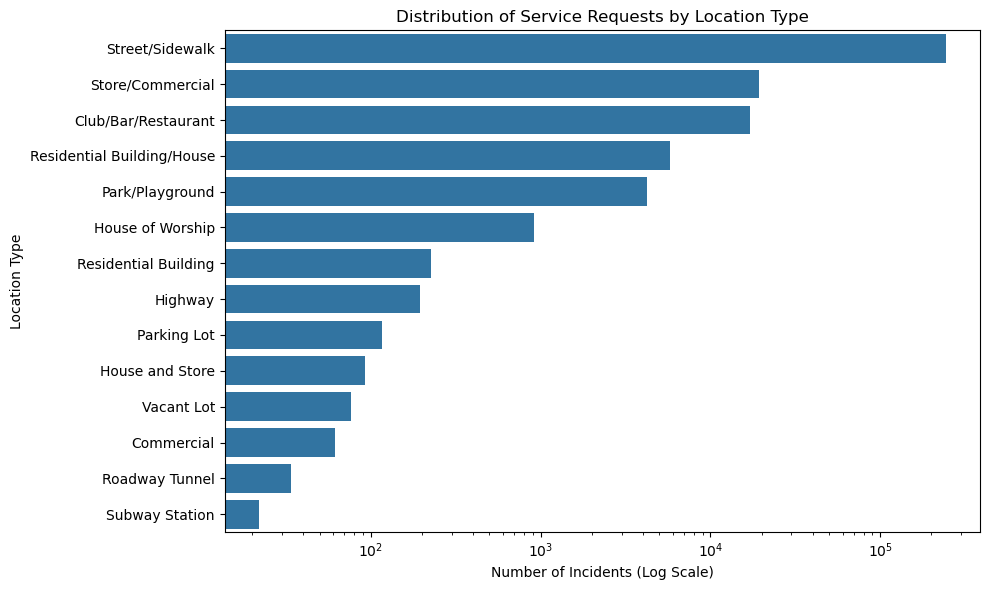

```python
plt.figure(figsize=(10, 6))
location_counts = data_set['Location Type'].value_counts()
sns.barplot(x=location_counts.values, y=location_counts.index)
plt.xscale('log')  #Log scale to handle large amount of data
plt.title('Distribution of Service Requests by Location Type')
plt.xlabel('Number of Incidents (Log Scale)')
plt.ylabel('Location Type')
plt.tight_layout()
plt.show()
```

**Complaint Type Influences Request Closing Time**

[figure not shown]

```python
plt.figure(figsize=(10, 6)) #size
sns.violinplot(x='Complaint Type', y='Request_Closing_Time', data=data_set)
plt.xticks(rotation=45)
plt.title('Request Closing Time by Complaint Type')
plt.xlabel('Complaint Type')
plt.ylabel('Request Closing Time (Days)')
plt.show() #graph
```

**Monthly Complaint Trends**

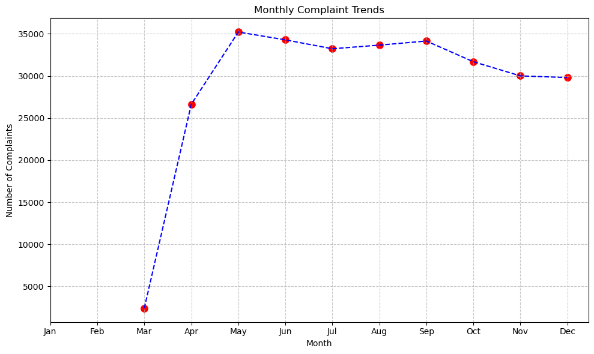

```python
#extract month from Created Date
data_set['Month'] = data_set['Created Date'].dt.month

#complaints by month
monthly_counts = data_set.groupby('Month').size().reset_index(name='Complaint Count')

#scatter plot with line to connect
plt.figure(figsize=(10, 6))
sns.scatterplot(x='Month', y='Complaint Count', data=monthly_counts, s=100, color='red')
sns.lineplot(x='Month', y='Complaint Count', data=monthly_counts, color='blue', linestyle='--')
plt.title('Monthly Complaint Trends')
plt.xlabel('Month')
plt.ylabel('Number of Complaints')
plt.xticks(ticks=range(1, 13), labels=['Jan', 'Feb', 'Mar', 'Apr', 'May', 'Jun', 'Jul', 'Aug', 'Sep', 'Oct', 'Nov', 'Dec'])
plt.grid(True, linestyle='--', alpha=0.7)
plt.tight_layout()
plt.show()
```

**Arrangement and Graph**

[figure not shown]

```python
#Group by Borough and Complaint Type, compute mean Request_Closing_Time
avg_closing_time = data_set.groupby(['Location Type', 'Complaint Type'])['Request_Closing_Time'].mean().reset_index()
#Group by Request_Closing_Time within each Borough
avg_closing_time = avg_closing_time.sort_values(by=['Location Type', 'Request_Closing_Time'], ascending=[True, False])
pivot_data = avg_closing_time.pivot(index='Location Type', columns='Complaint Type', values='Request_Closing_Time').fillna(0)

# Create heatmap
plt.figure(figsize=(18, 8))
sns.heatmap(pivot_data, annot=True, fmt='.2f', cmap='Reds', cbar_kws={'label': 'Average Request Closing Time (Days)'}, linewidths=0.5)
plt.title('Heatmap of Average Request Closing Time by Complaint Type and Location Type', fontsize=14)
plt.xlabel('Complaint Type', fontsize=12)
plt.ylabel('Location Type', fontsize=12)
plt.xticks(rotation=35, ha='right', fontsize=10)
plt.yticks(fontsize=10)
plt.tight_layout()
plt.show()
```

**Test 1: Whether the average response time across complaint types is similar or not**

```python
from scipy.stats import f_oneway

#grouping request closing time according to complaint type
groups = [group['Request_Closing_Time'].values for name, group in data_set.groupby('Complaint Type')]

#one-way ANOVA test
f_stat, p_value = f_oneway(*groups)

#overall mean
overall_mean = data_set['Request_Closing_Time'].mean()

#Interpretation
print("F-statistic: " + str(f_stat))
print("P-value: " + str(p_value))
print("Overall Mean Request_Closing_Time: " + str(overall_mean) + "days")
alpha = 0.05
if p_value < alpha:
    print("Reject the null hypothesis: Mean is significantly different.")
else:
    print("Fail to reject the null hypothesis: No significant difference.")
```

[output not shown]

**Test 2: Whether the type of complaint or service requested and location are related.**

```python
from scipy.stats import chi2_contingency

#contingency table
contingency_table = pd.crosstab(data_set['Complaint Type'], data_set['Location Type'])

#Chi-Square Test
chi2_stat, p_value, dof, expected = chi2_contingency(contingency_table)

print("\nTest 2: Chi-Square Test Results")
print("Chi-Square Statistic: " + str(chi2_stat))
print("P-value: " +str(p_value))
print("Degrees of Freedom: "+str(dof))

#Interpretation
alpha = 0.05
if p_value < alpha:
    print("Reject the null hypothesis: Complaint Type and Location are related.")
else:
    print("Fail to reject the null hypothesis: Complaint Type and Location are independent.")
```

```
Test 2: Chi-Square Test Results
Chi-Square Statistic: 1049203.872020897
P-value: 0.0
Degrees of Freedom: 182
Reject the null hypothesis: Complaint Type and Location are related.
```